# Biostats_Mod1

Shea Zhao

## About Our Data

Our data comes from: https://vincentarelbundock.github.io/Rdatasets/datasets.html We will be using the dataset “socsupport.csv” from R package DAAG. The data dictionary is here: https://vincentarelbundock.github.io/Rdatasets/doc/DAAG/socsupport.html

## Identify Varibles

Identify at least 3 quantitative variables and 2 categorical variables that they will analyze using research questions.

```r
# first load & view the data
data <- read.csv("/Users/shea/Documents/Berkeley Biostats/socsupport.csv")
head(data)
```

```
##   X gender   age   country marital   livewith         employment
## 1 1   male 21-24 australia   other    partner employed part-time
## 2 2 female 21-24 australia  single    partner   parental support
## 3 3   male 21-24 australia  single residences employed part-time
## 4 4   male 18-20 australia  single    parents employed part-time
## 5 5 female 21-24 australia  single    friends employed part-time
## 6 6 female 21-24 australia  single    friends    govt assistance
##      firstyr enrolment emotional emotionalsat tangible tangiblesat affect
## 1      other full-time        22           23       17          18     15
## 2      other full-time        21           20       12          10     10
## 3      other full-time        21           18       16          16     15
## 4 first year full-time        19           19       20          17     11
## 5      other full-time        16           19       11          15      6
## 6      other full-time        20           17       16          15     12
##   affectsat psi psisat esupport psupport supsources BDI
## 1        15  12     13       13       11         13   5
## 2         6   9      6       12        7         10   8
## 3        15  13     12       14       13         14  16
## 4        11  13     12       15       15         15   0
## 5        10  11     12        9        7          9   9
## 6        14  12     11       13       12         13   0
```

The documentation describes this dataset as on “social and other kinds of support”.Some of the variables are self-explanatory, i.e.“gender” has two levels: “female” & “male”. The levels for other variables are less interpretable, so we’ll need to take a closer look at them and make an educated guess.

```
g <- (levels(my_data$gender))
View(g)
```

The variable, “country”, for instance, is less straight forward. It’s levels are “australia” & “other”

```
C <- (levels(my_data$country))
View(C)
```

“firstyr” is only described as “a factor with levels first year, other”. Perhaps level “first year” indicates the index survey measure & the level “other” indicates a follow-up survey?

“age” is described as “age, in years, with levels 18-20, 21-24, 25-30, 31-40,40+”. “marital” is a factor with levels married, other, single. “livewith” is a factor with levels alone, friends, other, parents, partner, residences. “employment” is a factor with levels employed fulltime, employed part-time, govt assistance, other, parental support. “enrolment” is a factor with levels full-time, part-time, .

The remaining variables are each a score of various indicators for emotional support measured by the survey.

```r
# we can verify this description of the data by looking at the structure of the dataset
str(data)
```

```
## 'data.frame':    95 obs. of  21 variables:
##  $ X           : int  1 2 3 4 5 6 7 8 9 10 ...
##  $ gender      : Factor w/ 2 levels "female","male": 2 1 2 2 1 1 1 1 1 2 ...
##  $ age         : Factor w/ 5 levels "18-20","21-24",..: 2 2 2 1 2 2 3 3 1 5 ...
##  $ country     : Factor w/ 2 levels "australia","other": 1 1 1 1 1 1 1 1 1 1 ...
##  $ marital     : Factor w/ 3 levels "married","other",..: 2 3 3 3 3 3 1 1 3 2 ...
##  $ livewith    : Factor w/ 6 levels "alone","friends",..: 5 5 6 4 2 2 5 5 4 1 ...
##  $ employment  : Factor w/ 5 levels "employed fulltime",..: 2 5 2 2 2 3 2 2 2 2 ...
##  $ firstyr     : Factor w/ 2 levels "first year","other": 2 2 2 1 2 2 2 2 2 2 ...
##  $ enrolment   : Factor w/ 3 levels "","full-time",..: 2 2 2 2 2 2 2 3 2 2 ...
##  $ emotional   : int  22 21 21 19 16 20 20 20 24 13 ...
##  $ emotionalsat: int  23 20 18 19 19 17 23 20 25 18 ...
##  $ tangible    : int  17 12 16 20 11 16 20 16 20 6 ...
##  $ tangiblesat : int  18 10 16 17 15 15 20 16 20 14 ...
##  $ affect      : int  15 10 15 11 6 12 14 12 15 6 ...
##  $ affectsat   : int  15 6 15 11 10 14 15 12 15 12 ...
##  $ psi         : int  12 9 13 13 11 12 15 12 12 6 ...
##  $ psisat      : int  13 6 12 12 12 11 15 12 15 11 ...
##  $ esupport    : int  13 12 14 15 9 13 15 13 16 10 ...
##  $ psupport    : int  11 7 13 15 7 12 10 11 NA 8 ...
##  $ supsources  : int  13 10 14 15 9 13 13 11 NA 9 ...
##  $ BDI         : int  5 8 16 0 9 0 1 14 12 20 ...
```

## Feature Engineering

We’ll need to prepare our data before we can begin to analyze it.

```r
summary(data)
```

```
##        X           gender      age          country      marital
##  Min.   : 1.0   female:71   18-20:44   australia:85   married: 9
##  1st Qu.:24.5   male  :24   21-24:35   other    :10   other  :10
##  Median :48.0               25-30: 6                  single :76
##  Mean   :48.0               31-40: 6
##  3rd Qu.:71.5               40+  : 4
##  Max.   :95.0
##
##        livewith               employment       firstyr       enrolment
##  alone     : 2   employed fulltime : 2   first year:24            : 4
##  friends   : 7   employed part-time:45   other     :71   full-time:79
##  other     : 3   govt assistance   :14                   part-time:12
##  parents   :41   other             :15
##  partner   :21   parental support  :19
##  residences:21
##
##    emotional      emotionalsat      tangible      tangiblesat
##  Min.   : 6.00   Min.   : 8.00   Min.   : 4.00   Min.   : 8.00
##  1st Qu.:17.00   1st Qu.:19.00   1st Qu.:14.00   1st Qu.:15.75
##  Median :20.00   Median :20.00   Median :18.00   Median :18.00
##  Mean   :19.24   Mean   :19.88   Mean   :16.41   Mean   :17.01
##  3rd Qu.:21.00   3rd Qu.:22.00   3rd Qu.:20.00   3rd Qu.:20.00
##  Max.   :25.00   Max.   :25.00   Max.   :20.00   Max.   :20.00
##                  NA's   :1       NA's   :1       NA's   :3
##      affect        affectsat          psi            psisat
##  Min.   : 3.00   Min.   : 3.00   Min.   : 5.00   Min.   : 5.00
##  1st Qu.:10.00   1st Qu.:11.00   1st Qu.:11.00   1st Qu.:11.00
##  Median :13.00   Median :13.00   Median :12.00   Median :12.00
##  Mean   :11.99   Mean   :12.33   Mean   :11.78   Mean   :12.17
##  3rd Qu.:15.00   3rd Qu.:15.00   3rd Qu.:14.00   3rd Qu.:14.00
##  Max.   :15.00   Max.   :15.00   Max.   :15.00   Max.   :15.00
##
##     esupport        psupport       supsources         BDI
##  Min.   : 6.00   Min.   : 4.00   Min.   : 5.00   Min.   : 0.00
##  1st Qu.:11.00   1st Qu.: 8.00   1st Qu.: 9.00   1st Qu.: 5.00
##  Median :13.00   Median :10.00   Median :11.00   Median : 9.00
##  Mean   :12.77   Mean   :10.33   Mean   :10.81   Mean   :10.76
##  3rd Qu.:14.00   3rd Qu.:13.00   3rd Qu.:13.00   3rd Qu.:14.00
##  Max.   :19.00   Max.   :20.00   Max.   :16.00   Max.   :48.00
##  NA's   :1       NA's   :2       NA's   :2
```

```r
#install.packages("ggplot2") # install ggplot if you haven't alredy
library(ggplot2)

# now we can make histograms, density curves, and boxplots, but first we'll need to convert the "integer"" variables to "numeric"
sapply(data, class) # notice variables like BDI are classified as "integer"
```

```
##            X       gender          age      country      marital
##    "integer"     "factor"     "factor"     "factor"     "factor"
##     livewith   employment      firstyr    enrolment    emotional
##     "factor"     "factor"     "factor"     "factor"    "integer"
## emotionalsat     tangible  tangiblesat       affect    affectsat
##    "integer"    "integer"    "integer"    "integer"    "integer"
##          psi       psisat     esupport     psupport   supsources
##    "integer"    "integer"    "integer"    "integer"    "integer"
##          BDI
##    "integer"
```

```r
# Let's make the data a dataframe so it's easier to work with
# You can think of a DataFrame as a group of Series that share an index (in this case the column headers). This makes it easy to select specific columns.

my_data <- as.data.frame(data)
head(my_data)
```

```
##   X gender   age   country marital   livewith         employment
## 1 1   male 21-24 australia   other    partner employed part-time
## 2 2 female 21-24 australia  single    partner   parental support
## 3 3   male 21-24 australia  single residences employed part-time
## 4 4   male 18-20 australia  single    parents employed part-time
## 5 5 female 21-24 australia  single    friends employed part-time
## 6 6 female 21-24 australia  single    friends    govt assistance
##      firstyr enrolment emotional emotionalsat tangible tangiblesat affect
## 1      other full-time        22           23       17          18     15
## 2      other full-time        21           20       12          10     10
## 3      other full-time        21           18       16          16     15
## 4 first year full-time        19           19       20          17     11
## 5      other full-time        16           19       11          15      6
## 6      other full-time        20           17       16          15     12
##   affectsat psi psisat esupport psupport supsources BDI
## 1        15  12     13       13       11         13   5
## 2         6   9      6       12        7         10   8
## 3        15  13     12       14       13         14  16
## 4        11  13     12       15       15         15   0
## 5        10  11     12        9        7          9   9
## 6        14  12     11       13       12         13   0
```

```r
cols.num <- c("emotional", "emotionalsat", "tangible", "tangiblesat", "affect","affectsat", "psi", "psisat", "esupport", "psupport", "supsources", "BDI")
my_data[cols.num] <- sapply(my_data[cols.num],as.numeric) # we save this to a new dataframe called "my_data""
sapply(my_data, class) # now BDI is "numeric"
```

```
##            X       gender          age      country      marital
##    "integer"     "factor"     "factor"     "factor"     "factor"
##     livewith   employment      firstyr    enrolment    emotional
##     "factor"     "factor"     "factor"     "factor"    "numeric"
## emotionalsat     tangible  tangiblesat       affect    affectsat
##    "numeric"    "numeric"    "numeric"    "numeric"    "numeric"
##          psi       psisat     esupport     psupport   supsources
##    "numeric"    "numeric"    "numeric"    "numeric"    "numeric"
##          BDI
##    "numeric"
```

## Basic Summary Stats

Identify 4-5 questions that can be answered by the file. These should involve the quantitative and categorical variables identified.

First let’s get a feel for our sample demographics - who’s in our dataset?

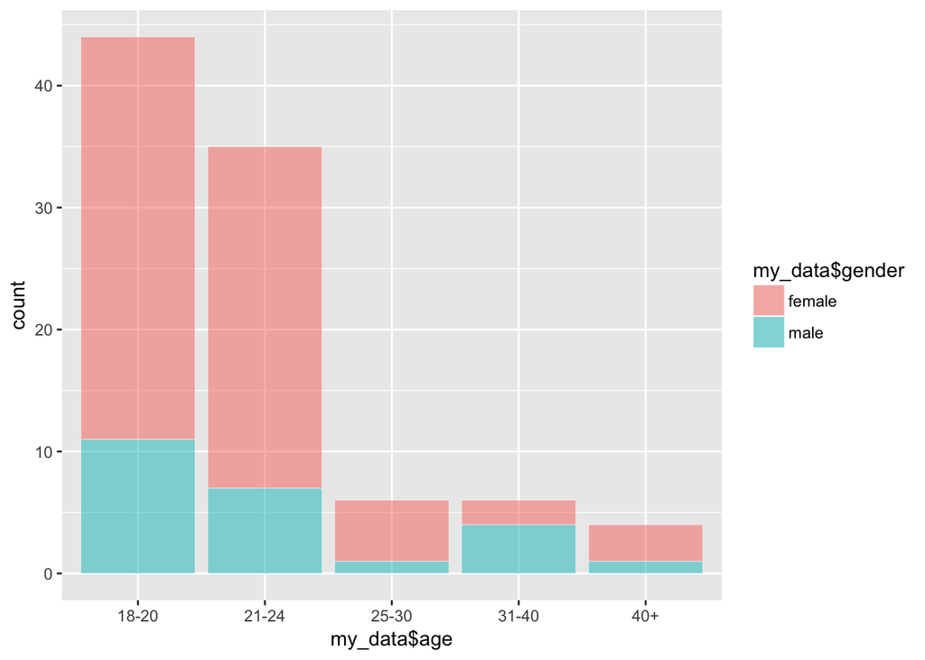

```r
ggplot(my_data, aes(x = my_data$age, fill = my_data$gender)) +
  geom_histogram(binwidth = 1, alpha=.5, size = 0.1,color="white", stat = "count") # use stat = "count" b/c age is discrete not continuous varible
```

The bargraph above shows that our sample is overwhelmingly female and relatively young.

```r
# install.packages("dplyr")
library(dplyr) # make sure you have dplyr!
library(magrittr) # and migrattr for  %>%
```

```r
# let's make a contigency table to look at mean age & gender

# the count & proportion of the sample by age

my_data %>%
  count(age) %>%
  mutate(prop = prop.table(n))
```

```
## # A tibble: 5 x 3
##   age       n   prop
##   <fct> <int>  <dbl>
## 1 18-20    44 0.463
## 2 21-24    35 0.368
## 3 25-30     6 0.0632
## 4 31-40     6 0.0632
## 5 40+       4 0.0421
```

```r
# the count & proportion of the sample by gender
my_data %>%
  count(gender) %>%
  mutate(prop = prop.table(n))
```

```
## # A tibble: 2 x 3
##   gender     n  prop
##   <fct>  <int> <dbl>
## 1 female    71 0.747
## 2 male      24 0.253
```

```r
# age & gender together
my_data %>%
  count(age, gender) %>%
  mutate(prop = prop.table(n))
```

```
## # A tibble: 10 x 4
##    age   gender     n   prop
##    <fct> <fct>  <int>  <dbl>
##  1 18-20 female    33 0.347
##  2 18-20 male      11 0.116
##  3 21-24 female    28 0.295
##  4 21-24 male       7 0.0737
##  5 25-30 female     5 0.0526
##  6 25-30 male       1 0.0105
##  7 31-40 female     2 0.0211
##  8 31-40 male       4 0.0421
##  9 40+   female     3 0.0316
## 10 40+   male       1 0.0105
```

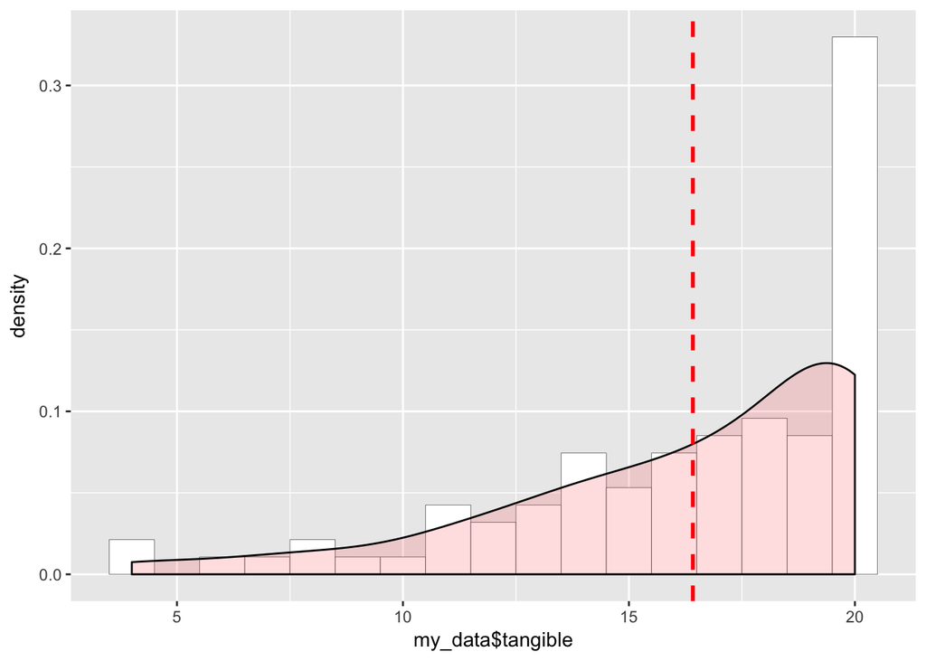

```r
ggplot(my_data,aes(x=my_data$`tangible`))+
  geom_histogram(aes(y=..density..), binwidth = 1,size = 0.1,      # Histogram with density instead of count on y-axis
               colour="black", fill="white") +
  geom_density(alpha=.2, fill="#FF6666") +
  geom_vline(aes(xintercept = mean(tangible, na.rm=T)),   # Ignore NA values for mean
             color = "red", linetype = "dashed", size=1)
```

We can also look at variables multiple variables at once - like th affect of social support, measured by “affect”, and how it is distributed by age:

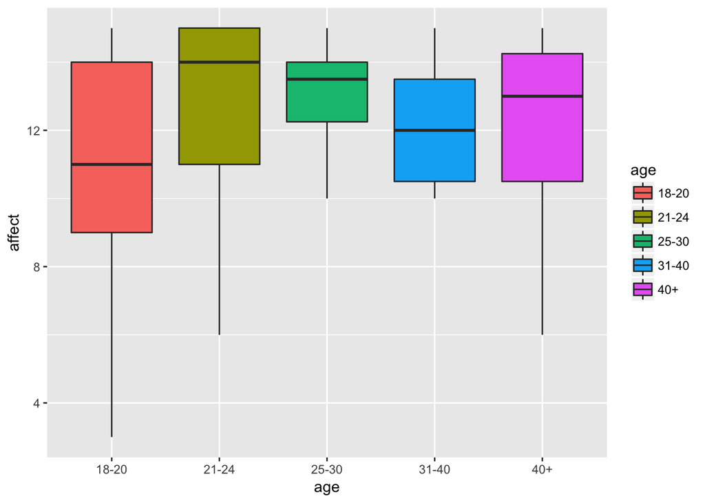

```r
ggplot(my_data, aes(x = age, y = affect, fill = age)) + geom_boxplot()
```

Perhpas we would like to know how Beck Depression Index (BDI) scores are associated with emotional support by gender? Adding a regression line will enable us to more clearly see if there are any trends as well as the 95% confidence interval.

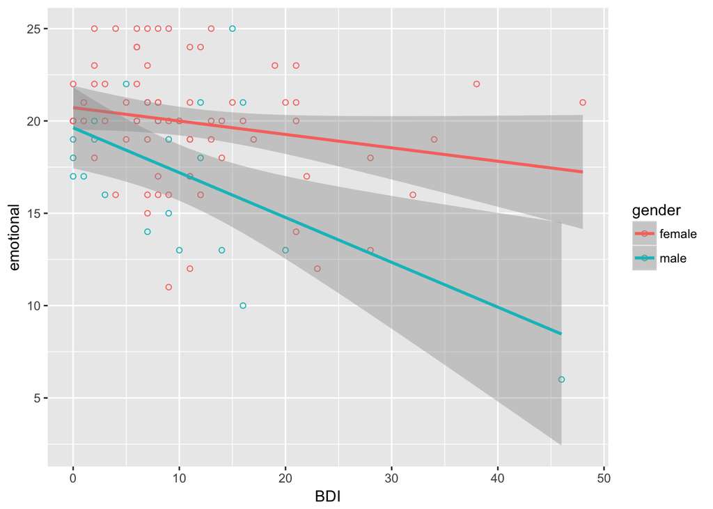

```r
ggplot(my_data, aes(x = BDI, y = emotional, color = gender)) +
  geom_point(shape=1) +    # Use hollow circles
  geom_smooth(method=lm)   # Add linear regression line
```

```r
#  (by default includes 95% confidence region)
```

We can further calculate the correlation between specific variables like gender and marital status, for example.

```r
cor(rank(my_data$gender), rank(my_data$marital)) # us spearman rank correlation for non-numeric variables
```

```
## [1] 0.004434958
```